# Data Science Salary Insights: A Visual Analysis

Mehmet Mert Tezcan

2022-2023

# 1. Introduction

This project is a data visualization analysis of the salary data of data science professionals. The goal of this project is to understand and visualize the factors that influence data science salaries, such as experience level, job title, and geographic location.

The data for this project comes from a dataset of data science job salaries, which includes information on the salary, experience level, job title, employment type, and location of each data science professional. The dataset contains information on a total of 607 data science professionals.

Overall, this project provides valuable insights into the data science job market, and can be useful for data science professionals looking to understand the factors that influence their salary.

# 2. Importing Libraries

In this section, we will import the necessary libraries for the project. Libraries are collections of functions and data that can be used to perform specific tasks, such as data manipulation, visualization, and statistical analysis.

To import the libraries, we will use the library() function in R. We will specify the name of the library as an argument to the function. For example, to import the tidyverse library, we would use the following code: library(tidyverse).

In this project, we will be using several libraries, including tidyverse, rnaturalearth, sf, and dplyr.

We will also check if the rnaturalearthhires library is installed, and if not, we will install it using the renv package.

Finally, we will use the sf::sf_use_s2() function to disable S2 geometries in the sf library.

By the end of this section, we will have all the necessary libraries imported and ready for use in the project.

```r
library(tidyverse)
library(rnaturalearth)
library(sf)
library(dplyr)

if (!require(rnaturalearthhires)) {
  if (!require(renv)) {
    install.packages("renv")
  }
  renv::install("rnaturalearth", "ropensci/rnaturalearthhires")
}

sf::sf_use_s2(FALSE)
```

# 3. Importing The Dataset

In this section, we will import the data science job salaries dataset into our analysis. This will involve reading the dataset from a file or database, and storing it in a data structure such as a tibble.

To import the dataset, we will use the read_csv() function from the tidyverse package. This function will allow us to read a CSV file and store it as a tibble, which is a modern data frame that is optimized for working with data in R.

We will also specify the location of the dataset file, either by providing a file path or URL.

By the end of this section, we will have the data science job salaries dataset imported and stored as a tibble, ready for further analysis.

```r
salaries <- read_csv("./data/ds_salaries.csv")
salaries <- select(salaries, -1)
head(salaries)
```

```
## # A tibble: 6 × 11
##   work_…¹ exper…² emplo…³ job_t…⁴ salary salar…⁵ salar…⁶ emplo…⁷ remot…⁸ compa…⁹
##     <dbl> <chr>   <chr>   <chr>    <dbl> <chr>     <dbl> <chr>     <dbl> <chr>
## 1    2020 MI      FT      Data S…  70000 EUR       79833 DE            0 DE
## 2    2020 SE      FT      Machin… 260000 USD      260000 JP            0 JP
## 3    2020 SE      FT      Big Da…  85000 GBP      109024 GB           50 GB
## 4    2020 MI      FT      Produc…  20000 USD       20000 HN            0 HN
## 5    2020 SE      FT      Machin… 150000 USD      150000 US           50 US
## 6    2020 EN      FT      Data A…  72000 USD       72000 US          100 US
## # … with 1 more variable: company_size <chr>, and abbreviated variable names
## #   ¹work_year, ²experience_level, ³employment_type, ⁴job_title,
## #   ⁵salary_currency, ⁶salary_in_usd, ⁷employee_residence, ⁸remote_ratio,
## #   ⁹company_location
```

# 4. Data Preparation

It’s always a good idea to check for missing values in the dataset, as these can cause errors or bias in our analysis. We can use functions such as is.na() or summarize_all() to identify which columns have missing values and how many.

```r
# Check for missing values in all columns
summarize_all(salaries, funs(sum(is.na(.))))
```

```
## # A tibble: 1 × 11
##   work_…¹ exper…² emplo…³ job_t…⁴ salary salar…⁵ salar…⁶ emplo…⁷ remot…⁸ compa…⁹
##     <int>   <int>   <int>   <int>  <int>   <int>   <int>   <int>   <int>   <int>
## 1       0       0       0       0      0       0       0       0       0       0
## # … with 1 more variable: company_size <int>, and abbreviated variable names
## #   ¹work_year, ²experience_level, ³employment_type, ⁴job_title,
## #   ⁵salary_currency, ⁶salary_in_usd, ⁷employee_residence, ⁸remote_ratio,
## #   ⁹company_location
```

Perfect! Our dataset does not contain any missing values. Also it looks like the dataset does not need any further steps of data cleaning, but we can do some improvements to have more readable dataset. For instance, the experience levels are indicated as “EN, MI, SE, and EX” and it is possible to mutate them to more human-readable format such as “Entry Level, Mid Level, Senior Level, and Executive Level”.

This also applies to the employment type column.

```r
salaries <- salaries %>%
  mutate(experience_level = as.factor(
    ifelse(experience_level == "EN", "Entry-Level",
           ifelse(experience_level == "MI", "Mid-Level",
                  ifelse(experience_level == "SE", "Senior-Level", "Executive-Level"))
    )
  ))

salaries <- salaries %>%
  mutate(employment_type = as.factor(
    ifelse(employment_type == "FT", "Full-Time",
           ifelse(employment_type == "CT", "Contract",
                  ifelse(employment_type == "FL", "Freelance", "Part-Time"))
    )
  ))
```

# 5. Data Visualization

In this section, we will delve into the nuances of data science salaries using a series of visualizations. By analyzing the distribution of experience levels and employment types, we will gain a better understanding of how these factors affect salaries among data scientists. Additionally, we will explore the correlation between salary and company size and experience level. Furthermore, we will examine the most common job titles and identify the countries with the highest concentration of data science professionals.

To gain a deeper insight, we will investigate the global distribution of salaries, and how it is affected by GDP per capita. Overall, these visualizations will provide valuable insights into the trends and patterns in the data, and assist us in comprehending the various factors that shape data science salaries.

## 5.1. Experience Level Distribution

This plot shows the distribution of experience levels among the data scientists in the dataset. It will give us an idea of the career progression and salary expectations for data scientists at different levels of experience.

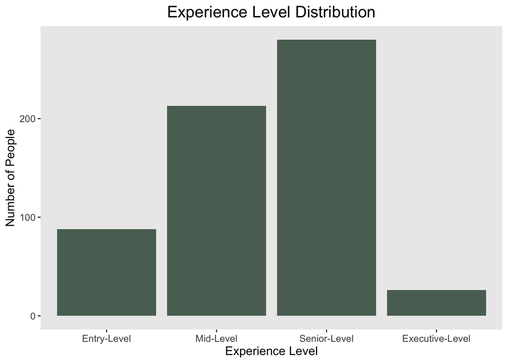

```r
salaries$experience_level <- factor(salaries$experience_level,
                  levels = c("Entry-Level", "Mid-Level", "Senior-Level", "Executive-Level"))

salaries %>%
  ggplot(aes(x = experience_level)) +
  geom_bar(fill = "#596F62") +
  labs(x = "Experience Level", y = "Number of People", title = "Experience Level Distribution") +
  theme(panel.grid.major = element_blank(),
        panel.grid.minor = element_blank(),
        text = element_text(size = 12),
        plot.title = element_text(size = 16, hjust = 0.5))
```

## 5.2. Salaries by Experience Level

This plot shows the distribution of salaries for different experience levels in the data science field. The x-axis represents the different experience levels (entry-level, mid-level, senior-level, executive-level) and the y-axis represents the salary in USD. The boxplot gives an idea of the range, median and outliers of salary for each experience level.

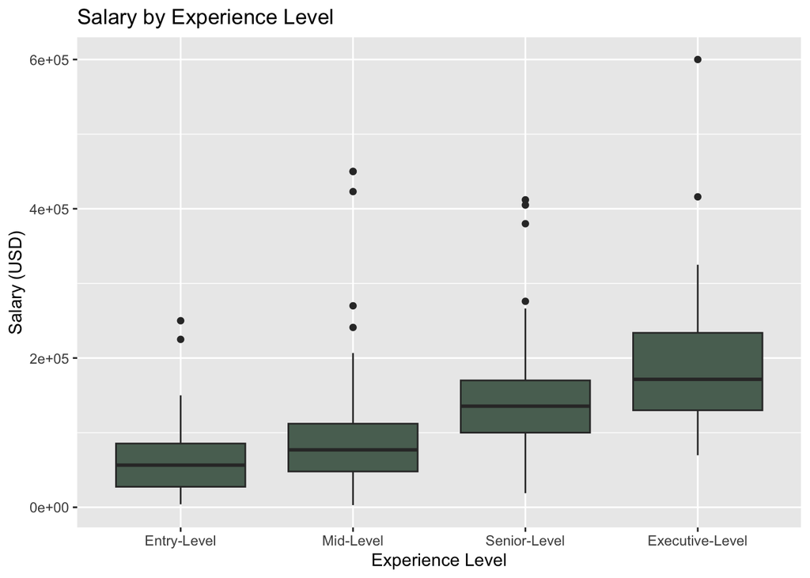

```r
# Create the boxplot
salaries %>%
  ggplot(aes(x=experience_level, y=salary_in_usd)) +
  geom_boxplot(fill = "#596F62") +
  labs(title = "Salary by Experience Level",
    x = "Experience Level",
    y = "Salary (USD)"
  )
```

This can be a useful way to understand how experience level affects salary in the data science field. Additionally, a clear difference in the median salary can be seen between the different experience levels.

## 5.3. Salaries by Company Size and Experience Level

This plot shows the distribution of salaries by experience level and company size. The x-axis represents the experience level of the data scientists, with levels including Entry-level, Mid-level, Senior-level, and Executive-level. The y-axis represents the salary in USD. The plot is separated into three facets, one for each company size: S, M, and L, with the size of the company (small, medium, large) labeled on the top of each facet. The plot uses boxplots to visualize the median, upper and lower quartiles of the salary, and the whiskers extend to the minimum and maximum salary values that are not outliers. The boxes are filled with different colors, to correspond to the experience level.

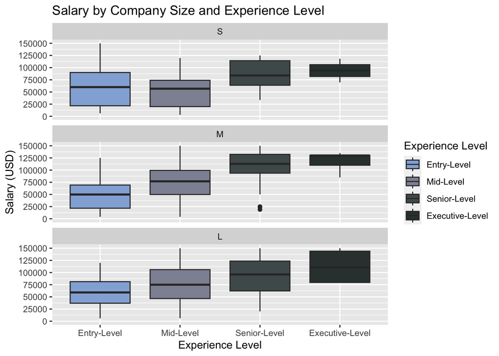

```r
salaries %>%
  mutate(company_size_order = fct_relevel(company_size, c("S","M","L"))) %>%
  ggplot(aes(x=experience_level, y=salary_in_usd)) +
  geom_boxplot(aes(fill = experience_level)) +
  labs(title = "Salary by Company Size and Experience Level",
    x = "Experience Level",
    y = "Salary (USD)"
  ) +
  facet_wrap(~company_size_order, ncol=1) +
  scale_y_continuous(limits = c(0, 150000),breaks = c(0, 25000, 50000, 75000, 100000, 125000, 150000)) +
  scale_fill_manual(name = "Experience Level",
                     labels = c("Entry-Level", "Mid-Level", "Senior-Level", "Executive-Level"),
                     values = c("#94B0DA", "#8F91A2", "#505A5B", "#343F3E"))
```

From this plot, it is possible to compare the salary distribution across experience levels and company sizes and identify patterns or variations. It can be observed that the salary range for entry-level and mid-level is quite similar and range between 25K to 100K, whereas senior-level and executive-level range is higher. The salary distribution in small companies is mostly similar with the medium and large companies. Overall, the executive-level employees have the highest salary compared to entry, mid and senior level, as expected.

## 5.4. Employment Type Distribution

The ‘Employment Type Distribution’ plot shows the breakdown of data science jobs by employment type. This information is important because employment type can affect things like job security, benefits, and the ability to work remotely. By understanding the distribution of employment types in the data science job market, data scientists and employers can better understand the opportunities and challenges that different employment types may present.

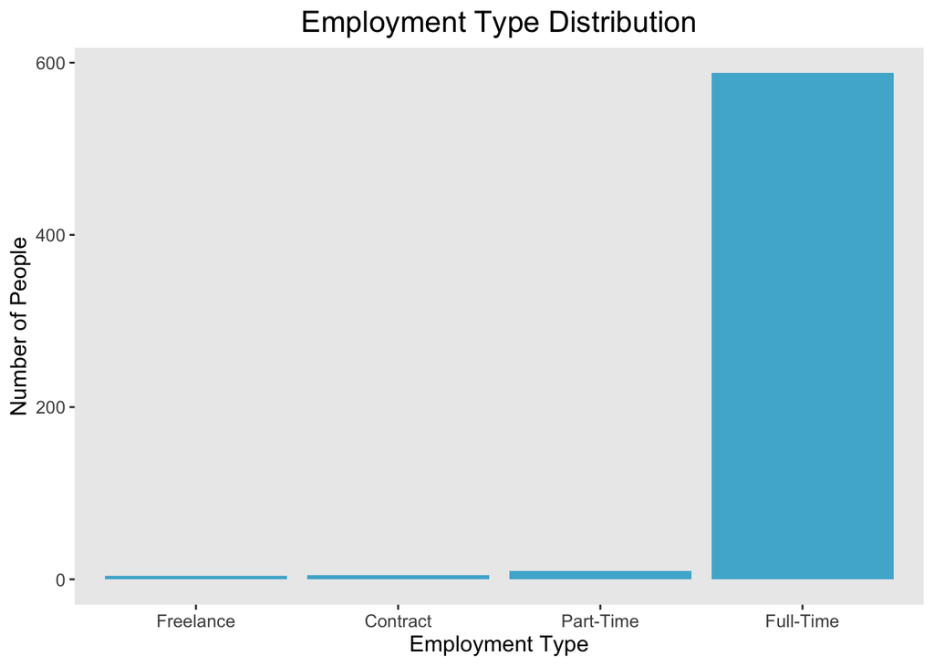

```r
salaries$employment_type <- factor(salaries$employment_type,# Change ordering manually
                  levels = c("Freelance", "Contract", "Part-Time", "Full-Time"))
salaries %>%
  ggplot(aes(x = employment_type,
             fill=employment_type)) +
  geom_bar(fill = "#4EB3D3") +
  labs(title = "Employment Type Distribution",
       x = "Employment Type",
       y = "Number of People") +
  theme(panel.grid.major = element_blank(),
        panel.grid.minor = element_blank(),
        text = element_text(size = 12),
        plot.title = element_text(size = 16, hjust = 0.5))
```

The “Employment Type Distribution” plot shows that the majority of the data science professionals in the dataset are employed on a full-time basis, with relatively small percentages of freelance, contract, and part-time employment. It’s worth noting that the sample size for these employment types is much smaller than that of full-time employment, so it may not be representative of the overall employment type distribution within the data science industry. Additionally, it’s important to consider the possibility that the inclusion of more data from additional sources might result in different proportions of employment types. It would be interesting to further explore the relationship between employment type and other factors, such as salary or job title, to see if there are any significant trends or patterns.

## 5.5. Salaries by Employment Type

This violin plot shows the distribution of salaries by employment type. The x-axis displays the different types of employment (Freelance, Contract, Part-Time, and Full-Time) and the y-axis displays the salary in USD. Each violin shape represents the distribution of the salary data for each employment type and the width of the violin shape represents the frequency of the data points within that range of salary.

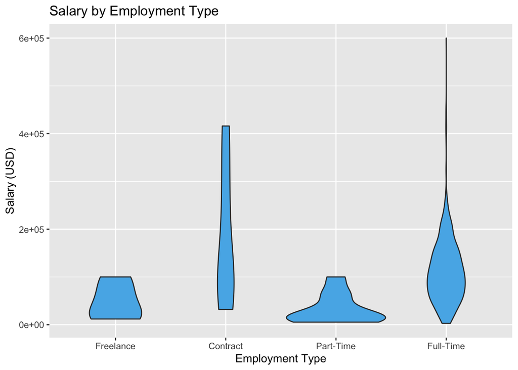

```r
# Create the violin plot
salaries %>%
  ggplot(aes(x=employment_type, y=salary_in_usd)) +
  geom_violin(fill = "#56B4E9") +
  labs(title = "Salary by Employment Type",
    x = "Employment Type",
    y = "Salary (USD)"
  )
```

It allows to see the variation of salary within each category of employment and compare how it is different than others. Additionally, this plot also can demonstrate the possible outliers within each employment type that have higher or lower salary.

The job title is an important aspect of a data science professional’s identity and can reflect the specific skills, responsibilities, and expertise that they bring to the table. In this plot, we will examine the most common job titles among the data scientists in the dataset, and see how the number of professionals with each title compares to one another. This will give us an idea of the diversity and specialization of the data science job market, and help us understand the demand and supply of different roles in the industry.

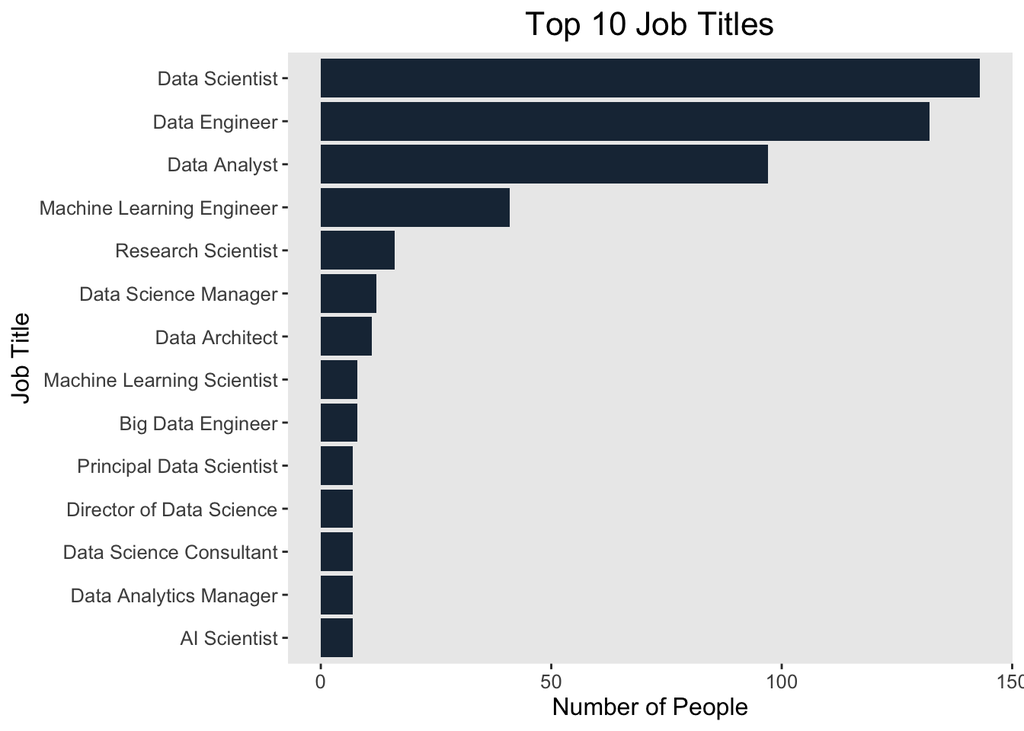

```r
salaries %>%
  group_by(job_title) %>%
  summarise(count = n()) %>%
  top_n(n = 10, wt = count) %>%
  ggplot(aes(x = reorder(job_title, count), y = count)) +
  geom_col(fill = "#1C3144") +
  coord_flip() +
  labs(title = "Top 10 Job Titles", x = "Job Title", y = "Number of People") +
  theme(panel.grid.major = element_blank(),
        panel.grid.minor = element_blank(),
        text = element_text(size = 12),
        plot.title = element_text(size = 16, hjust = 0.5))
```

The most common job title among the data scientists in the dataset is ‘Data Scientist’, which is not surprising given that it is a broad and widely recognized role in the field. However, it is interesting to see that ‘Data Engineer’ and ‘Machine Learning Engineer’ are also among the top 5 job titles, which suggests that there is strong demand for professionals with expertise in data infrastructure and machine learning applications.

It is also noteworthy that ‘Data Analyst’ and ‘Research Scientist’ are among the top 5 job titles, which indicates that there is a diverse range of roles and responsibilities within the data science profession. Data analysts often focus on the exploration and visualization of data, while research scientists may conduct more theoretical or applied research using data-driven methods.

Overall, this plot provides a useful overview of the job titles represented in the dataset and can help us understand the skills and areas of expertise that are most valued in the data science job market.

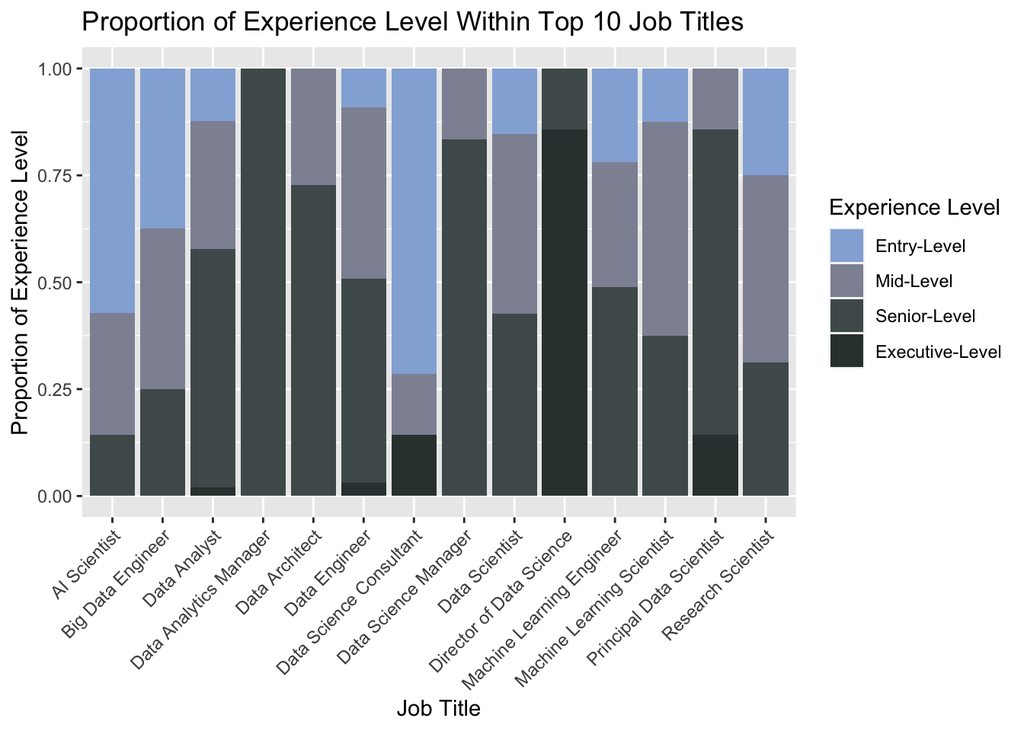

```r
top_job_titles <- salaries %>%
  group_by(job_title) %>%
  summarize(n = n()) %>%
  arrange(desc(n)) %>%
  top_n(10) %>%
  pull(job_title)

salaries %>%
  filter(job_title %in% top_job_titles) %>%
  group_by(job_title, experience_level) %>%
  summarize(n = n()) %>%
  group_by(job_title) %>%
  mutate(prop = n/sum(n)) %>%
  ggplot(aes(job_title, prop, fill = experience_level)) +
  geom_bar(stat = "identity", position = "fill") +
  labs(title = "Proportion of Experience Level Within Top 10 Job Titles",
       x = "Job Title",
       y = "Proportion of Experience Level") +
  theme(axis.text.x = element_text(angle = 45, hjust = 1)) +
    scale_fill_manual(name = "Experience Level",
                     labels = c("Entry-Level", "Mid-Level", "Senior-Level", "Executive-Level"),
                     values = c("#94B0DA", "#8F91A2", "#505A5B", "#343F3E"))
```

It is clear from the plot that the proportions of experience levels vary significantly among the different job titles. For example, the proportion of senior-level experience is much higher in the “Data Science Manager” job title compared to the “Data Scientist” job title. Additionally, we can see that the “AI Scientist” job title has a higher proportion of entry-level and mid-level experience compared to the other job titles. In general, it can be noted that more senior roles tend to have fewer entry-level and mid-level employees.

## 5.8. Number of Data Scientists by Continent and Country

In this section, we will be visualizing the distribution of data scientists by continent and country. This plot allows us to gain an understanding of which countries have a higher concentration of data scientists, and how they are distributed among different continents. To improve the accessibility for colorblind users, Paul Tol’s qualitative colorblind-friendly palette was used in this plot. Additionally, to help improve readability, countries with fewer data scientists were grouped and labeled collectively, making it easier to compare the relative number of data scientists across different countries.

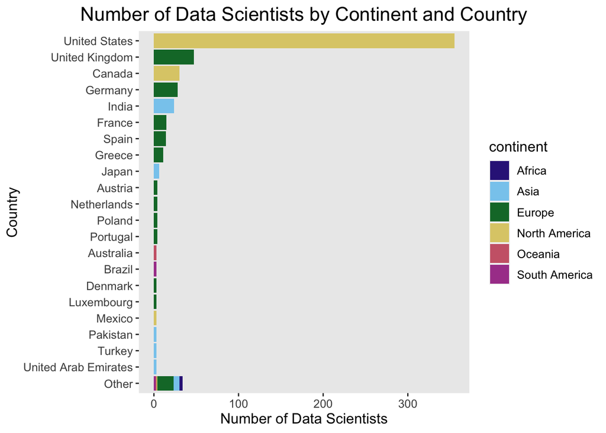

```r
world <- rnaturalearth::ne_countries(returnclass = "sf")
salaries_world <- left_join(world, salaries, by= c('iso_a2' = 'company_location')) %>%
  drop_na(job_title)

tol_qualitative <- c("#332288", "#88CCEE", "#117733", "#DDCC77", "#CC6677", "#AA4499")
salaries_world %>%
  group_by(continent, country = name) %>%
  summarise(num_data_scientists = n()) %>%
  ungroup() %>%
  drop_na() %>%
  mutate(
    country = fct_reorder(country, desc(num_data_scientists)),
    country = fct_lump_n(country, 20, w=num_data_scientists)
  ) %>%
  ggplot(aes(country, num_data_scientists, fill=continent)) +
  geom_col() +
  scale_fill_manual(values = tol_qualitative) +
  scale_x_discrete(limits = rev) +
  coord_flip() +
  labs(title = "Number of Data Scientists by Continent and Country",
    y = "Number of Data Scientists",
    x = "Country"
  ) +
  theme(panel.grid.major = element_blank(),
        panel.grid.minor = element_blank(),
        text = element_text(size = 12),
        plot.title = element_text(size = 16, hjust = 0.5))
```

## 5.9. Salaries Around the World

This plot allows us to see how data science salaries vary across different regions of the world and can help us understand the factors that influence these differences. For example, we might expect to see higher salaries in countries with higher GDP per capita, as these countries generally have a higher standard of living and may be able to offer higher salaries to attract top talent. Additionally, we can use this plot to identify any potential outliers or anomalies in the data, which may indicate the presence of additional factors that influence data science salaries in specific countries.

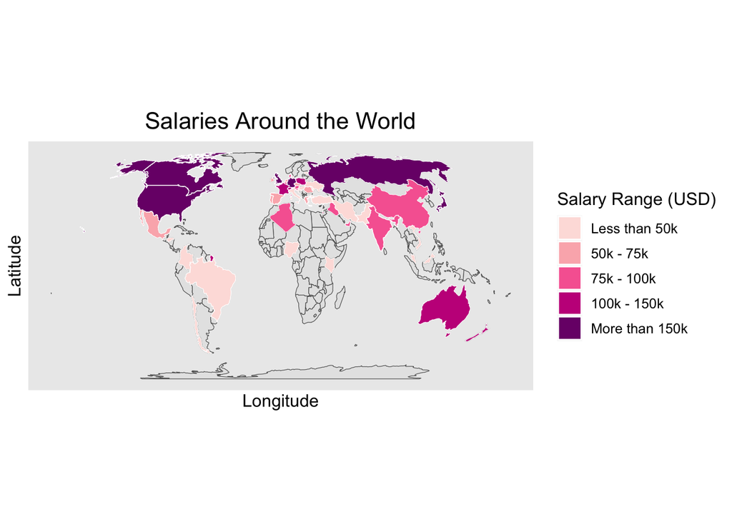

```r
salaries_ntile <- salaries_world %>%
  mutate(
    salary_usd_ntile = as.factor(ntile(x=salary_in_usd, n=5))
  )

ggplot(salaries_ntile) +
  geom_sf(data = world) +
  geom_sf(mapping = aes(fill = salary_usd_ntile),
          color = "white"
          ) +
  labs(
    title = "Salaries Around the World",
    x = "Longitude",
    y = "Latitude"
  ) +
  coord_sf(crs = "+proj=eqearth") +
  scale_fill_manual(name = "Salary Range (USD)",
                     labels = c("Less than 50k", "50k - 75k", "75k - 100k", "100k - 150k", "More than 150k"),
                     values = c("#FDE0DD", "#FBB4B9", "#F768A1", "#C51B8A", "#7A0177")) +
  theme(panel.grid.major = element_blank(),
        panel.grid.minor = element_blank(),
        text = element_text(size = 12),
        plot.title = element_text(size = 16, hjust = 0.5))
```

The ‘Salaries Around the World’ plot provides a detailed look at how data science salaries vary across different countries. As expected, we see higher salaries in countries with higher GDP per capita, such as the United States and Western European countries. However, we also see some countries with relatively low GDP per capita (such as Poland and Russia) that have relatively high salaries, which suggests that other factors, such as the demand for data science skills in these countries, may also be influencing salaries.

Overall, this plot provides valuable insights into the factors that influence data science salaries and can help data scientists and employers understand the competitive landscape of the data science job market around the world. Additionally, this plot can help policymakers and educators understand the demand for data science skills in different countries and regions, which can inform decisions about the allocation of resources and the development of data science education programs.

## 5.10. Correlation Between GDP per capita and Average Salary

In this plot, we are attempting to see if there is a correlation between the GDP per capita of a country and the average salary of data scientists in that country. The x-axis represents the GDP per capita and the y-axis represents the average salary. The plot shows the data points as well as a trendline to give a better idea of the relationship between the two variables. From the plot, we can see if there is a positive or negative correlation between the two variables and to what extent.

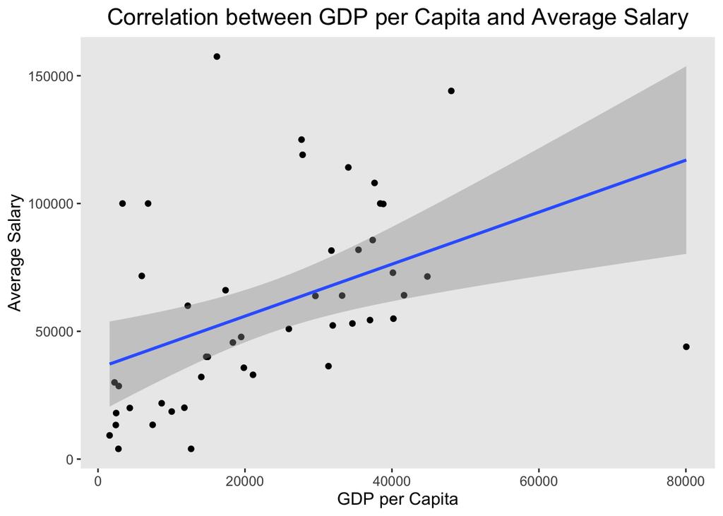

```r
gdpsalaries <- salaries_world %>%
  mutate(gdp_per_capita = as.numeric(gdp_md_est*1000000)/as.numeric(pop_est))

gdpsalaries %>%
  group_by(name, gdp_per_capita) %>%
  summarise(avg_salary = mean(salary_in_usd, na.rm=TRUE)) %>%
  ggplot(aes(x=gdp_per_capita, y=avg_salary)) +
  geom_point() +
  geom_smooth(method = "lm") +
  labs(title = "Correlation between GDP per Capita and Average Salary",
       x = "GDP per Capita",
       y = "Average Salary") +
  theme(panel.grid.major = element_blank(),
        panel.grid.minor = element_blank(),
        text = element_text(size = 12),
        plot.title = element_text(size = 16, hjust = 0.5))
```

From the plot, we can see that there is a positive correlation between GDP per capita and average salary, meaning that countries with higher GDP per capita tend to have higher average salaries for data scientists. This could be due to the fact that countries with higher GDP per capita generally have a higher standard of living and therefore are able to offer higher salaries to their employees. It’s worth noting that this plot is based on a small sample size and may not be representative of the entire population.

## 5.11. Heatmap for the GDP per capita and average salary correlation

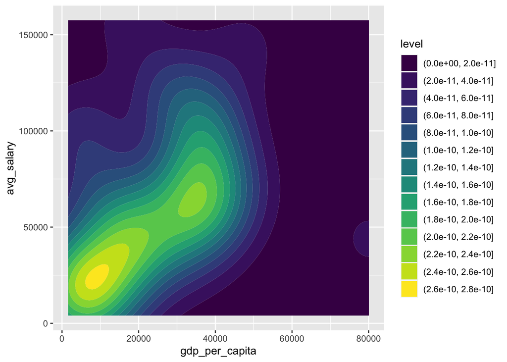

```r
gdpsalaries %>%
  group_by(name, gdp_per_capita) %>%
  summarise(avg_salary = mean(salary_in_usd, na.rm=TRUE)) %>%
  ggplot(aes(x=gdp_per_capita, y=avg_salary)) +
  stat_density_2d_filled()
```

In this plot, we visualize the relationship between GDP per capita and average salary for data scientists. The x-axis represents the GDP per capita of each country and the y-axis represents the average salary of data scientists in that country. The color intensity represents the density of data points at each location. From the plot, we can see that there is a positive correlation between GDP per capita and average salary, meaning that countries with higher GDP per capita tend to have higher average salaries for data scientists. This is likely because countries with higher GDP per capita tend to have stronger economies and higher demand for data science skills. However, it is important to note that this plot only represents a small group of people and may not be representative of the entire population.

# 6. Conclusion

Overall, this project illustrates the value of exploring salary data to gain a deeper understanding of the data science job market, and to make more informed decisions related to career or hiring. The insights obtained from this project can help data scientists to better negotiate their salaries, and employers to make more strategic decisions when it comes to hiring and retention. Additionally, this project could serve as a starting point for future research on data scientists’ salaries, as well as on other related topics in the field.